# Movie Recommender System

## 6.Preparing Data for Surprise

```python
reader = Reader(rating_scale=(0.5, 5.0))

data = Dataset.load_from_df(
    ratings[['userId', 'movieId', 'rating']],
    reader
)

trainset, testset = train_test_split(data, test_size=0.2, random_state=42)

print(f'Trainset size : {trainset.n_ratings:,}')
print(f'Testset size  : {len(testset):,}')
```

```
Trainset size : 80,000
Testset size  : 20,000
```

## 7.Model Comparison KNNBasic vs SVD

| Model | Type | Description |
| --- | --- | --- |
| KNNBasic | Memory-based | Finds similar items via cosine similarity; interpretable but slow at scale |
| SVD | Model-based | Matrix factorisation; fast, scalable, handles sparsity well |

```python
models = {
    "KNNBasic": KNNBasic(
        k=20,
        min_k=5,
        sim_options={
            'name': 'cosine',
            'user_based': False
        }
    ),
    "SVD": SVD(random_state=42)
}

results = []

for name, model in models.items():
    print(name)

    cv = cross_validate(
        model,
        data,
        measures=['RMSE', 'MAE'],
        cv=5,
        n_jobs=1
    )

    results.append({
        "Model": name,
        "RMSE": cv['test_rmse'].mean(),
        "MAE": cv['test_mae'].mean()
    })

comparison_df = pd.DataFrame(results)

comparison_df
```

```
KNNBasic
Computing the cosine similarity matrix...
Done computing similarity matrix.
Computing the cosine similarity matrix...
Done computing similarity matrix.
Computing the cosine similarity matrix...
Done computing similarity matrix.
Computing the cosine similarity matrix...
Done computing similarity matrix.
Computing the cosine similarity matrix...
Done computing similarity matrix.
SVD
```

|  | Model | RMSE | MAE |
| --- | --- | --- | --- |
| 0 | KNNBasic | 1.057158 | 0.836663 |
| 1 | SVD | 0.978650 | 0.755891 |

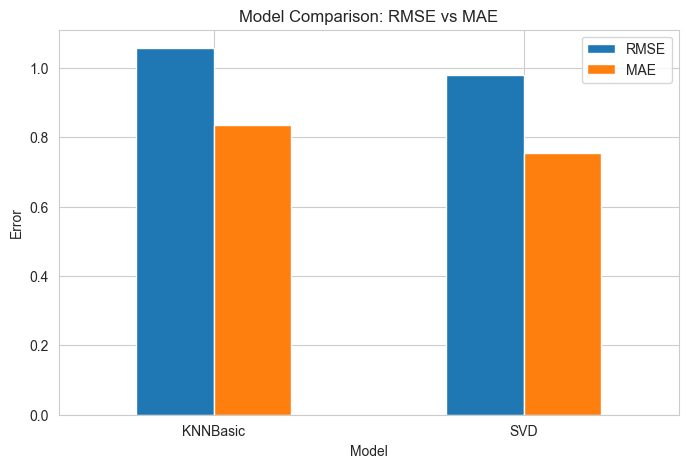

```python
comparison_df.plot(
    x="Model",
    y=["RMSE", "MAE"],
    kind="bar",
    figsize=(8,5)
)

plt.ylabel("Error")
plt.title("Model Comparison: RMSE vs MAE")
plt.xticks(rotation=0)
plt.show()
```

Lower RMSE = better predictions Lower MAE = better average error

## 8.Hyperparameter Tuning with GridSearchCV on SVD

```python
param_grid = {
    'n_factors': [50, 100],
    'n_epochs' : [20, 30],
    'lr_all'   : [0.002, 0.005],
    'reg_all'  : [0.02, 0.1]
}

gs = GridSearchCV(
    SVD,
    param_grid,
    measures=['rmse', 'mae'],
    cv=3,
    refit=True
)

gs.fit(data)

print('Best RMSE :', gs.best_score['rmse'])
print('Best MAE  :', gs.best_score['mae'])
print('Best params (RMSE):', gs.best_params['rmse'])
```

```
Best RMSE : 0.9768518727253438
Best MAE  : 0.753906667875813
Best params (RMSE): {'n_factors': 50, 'n_epochs': 30, 'lr_all': 0.005, 'reg_all': 0.1}
```

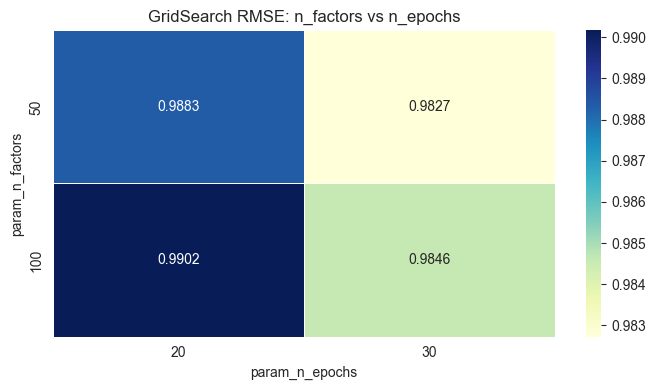

```python
#Visualise GridSearch results
results_df = pd.DataFrame(gs.cv_results)

pivot = results_df.pivot_table(
    values='mean_test_rmse',
    index='param_n_factors',
    columns='param_n_epochs'
)

plt.figure(figsize=(7, 4))
sns.heatmap(pivot, annot=True, fmt='.4f', cmap='YlGnBu', linewidths=0.5)
plt.title('GridSearch RMSE: n_factors vs n_epochs')
plt.tight_layout()
plt.show()
```

```python
#Train final tuned SVD model
best_params = gs.best_params['rmse']

best_model = SVD(
    n_factors=best_params['n_factors'],
    n_epochs =best_params['n_epochs'],
    lr_all   =best_params['lr_all'],
    reg_all  =best_params['reg_all'],
    random_state=42
)

best_model.fit(trainset)
predictions = best_model.test(testset)

print('Tuned SVD — Test Set Performance:')
print('RMSE:', accuracy.rmse(predictions))
print('MAE :', accuracy.mae(predictions))
```

```
Tuned SVD — Test Set Performance:
RMSE: 0.9749
RMSE: 0.974942618369937
MAE:  0.7523
MAE : 0.7522935508624818
```

## 9. Evaluation: Precision@K & Recall@K

RMSE and MAE measure rating accuracy, but for a Top-5 recommendation task, **Precision@K** and **Recall@K** are more business-relevant:

- **Precision@K** — of the Top-K movies recommended, what fraction did the user actually like?
- **Recall@K** — of all movies the user would have liked, what fraction did we surface in the Top-K?

A model can have low RMSE yet still rank irrelevant movies in the top 5.

```python
def precision_recall_at_k(predictions, k=5, threshold=3.5):

    user_ratings = defaultdict(list)

    # Group predictions by user
    for uid, _, true_r, est, _ in predictions:
        user_ratings[uid].append((est, true_r))

    precision_list = []
    recall_list = []

    for uid, ratings in user_ratings.items():

        # Sort by predicted rating
        ratings.sort(key=lambda x: x[0], reverse=True)

        # Top-K recommendations
        top_k = ratings[:k]

        # Relevant movies in whole test set
        relevant = sum(true_r >= threshold for _, true_r in ratings)

        # Relevant movies in top K
        relevant_top_k = sum(true_r >= threshold for _, true_r in top_k)

        precision = relevant_top_k / k

        recall = relevant_top_k / relevant if relevant > 0 else 0

        precision_list.append(precision)
        recall_list.append(recall)

    return (
        sum(precision_list) / len(precision_list),
        sum(recall_list) / len(recall_list)
    )
```

```python
p5, r5 = precision_recall_at_k(predictions, k=5)

print(f'Precision@5: {p5:.4f}')
print(f'Recall@5   : {r5:.4f}')
```

```
Precision@5: 0.1481
Recall@5   : 0.6748
```

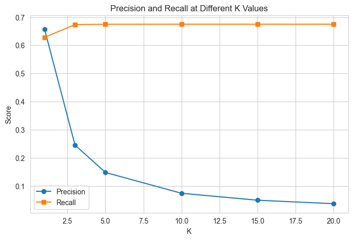

```python
k_values = [1, 3, 5, 10, 15, 20]

p_vals = []
r_vals = []

for k in k_values:
    p, r = precision_recall_at_k(predictions, k=k)
    p_vals.append(p)
    r_vals.append(r)

plt.figure(figsize=(8,5))

plt.plot(k_values, p_vals, marker='o', label='Precision')
plt.plot(k_values, r_vals, marker='s', label='Recall')

plt.title('Precision and Recall at Different K Values')
plt.xlabel('K')
plt.ylabel('Score')
plt.legend()

plt.show()
```

```python
# Final metrics summary table
# Get precision/recall at 10
p10, r10 = precision_recall_at_k(
    predictions,
    k=10,
    threshold=3.5
)
rmse_val = accuracy.rmse(predictions, verbose=False)
mae_val  = accuracy.mae(predictions,  verbose=False)

metrics_summary = pd.DataFrame({
    'Metric'    : ['RMSE', 'MAE', 'Precision@5', 'Recall@5', 'Precision@10', 'Recall@10'],
    'Tuned SVD' : [round(rmse_val, 4), round(mae_val, 4),
                   round(p5, 4), round(r5, 4),
                   round(p10, 4), round(r10, 4)],
    'Target'    : ['< 0.90', '< 0.70', '> 0.70', '> 0.40', '—', '—']
})
print('=== Metrics Summary ===')
print(metrics_summary.to_string(index=False))
```

```
=== Metrics Summary ===
      Metric  Tuned SVD Target
        RMSE     0.9749 < 0.90
         MAE     0.7523 < 0.70
 Precision@5     0.1481 > 0.70
    Recall@5     0.6748 > 0.40
Precision@10     0.0741      —
   Recall@10     0.6750      —
```

Top-5 Recommendation Engine

```python
def recommend_movies(user_id, ratings, movies, model, n=5, genre_filter=None):

    movie_ids = movies['movieId'].tolist()

    predictions = []

    for movie_id in movie_ids:
        if movie_id not in ratings[ratings.userId == user_id].movieId.values:
            pred = model.predict(user_id, movie_id)
            predictions.append((movie_id, pred.est))

    recs = pd.DataFrame(predictions, columns=['movieId', 'predicted_rating'])

    recs = recs.merge(movies, on='movieId')

    if genre_filter:
        recs = recs[recs.genres.str.contains(genre_filter, case=False)]

    return recs.sort_values(
        'predicted_rating',
        ascending=False
    ).head(n)
```

```python
# Example 1: Top-5 for user 1 (all genres)
print('=== Top-5 Recommendations for User 1 ===')
recommend_movies(user_id=1, ratings=ratings, movies=movies, model=best_model, n=5)
```

```
=== Top-5 Recommendations for User 1 ===
```

|  | movieId | predicted_rating | title | genres | genres_list |
| --- | --- | --- | --- | --- | --- |
| 314 | 318 | 4.368268 | Shawshank Redemption, The (1994) | Crime\|Drama | [Crime, Drama] |
| 840 | 858 | 4.325771 | Godfather, The (1972) | Crime\|Drama | [Crime, Drama] |
| 61090 | 202439 | 4.313486 | Parasite (2019) | Comedy\|Drama | [Comedy, Drama] |
| 2867 | 2959 | 4.300038 | Fight Club (1999) | Action\|Crime\|Drama\|Thriller | [Action, Crime, Drama, Thriller] |
| 909 | 930 | 4.297087 | Notorious (1946) | Film-Noir\|Romance\|Thriller | [Film-Noir, Romance, Thriller] |

```python
# Example 2: Top-5 Action movies for user 1
print('=== Top-5 Action Recommendations for User 1 ===')
recommend_movies(user_id=1, ratings=ratings, movies=movies,
                 model=best_model, n=5, genre_filter='Action')
```

```
=== Top-5 Action Recommendations for User 1 ===
```

|  | movieId | predicted_rating | title | genres | genres_list |
| --- | --- | --- | --- | --- | --- |
| 2867 | 2959 | 4.300038 | Fight Club (1999) | Action\|Crime\|Drama\|Thriller | [Action, Crime, Drama, Thriller] |
| 57705 | 195159 | 4.252523 | Spider-Man: Into the Spider-Verse (2018) | Action\|Adventure\|Animation\|Sci-Fi | [Action, Adventure, Animation, Sci-Fi] |
| 1201 | 1233 | 4.245181 | Boot, Das (Boat, The) (1981) | Action\|Drama\|War | [Action, Drama, War] |
| 1221 | 1254 | 4.240787 | Treasure of the Sierra Madre, The (1948) | Action\|Adventure\|Drama\|Western | [Action, Adventure, Drama, Western] |
| 5905 | 6016 | 4.210226 | City of God (Cidade de Deus) (2002) | Action\|Adventure\|Crime\|Drama\|Thriller | [Action, Adventure, Crime, Drama, Thriller] |